```python
from IPython.display import HTML

HTML('''<script>
code_show=true;
function code_toggle() {
 if (code_show){
 $('div.input').hide();
 $('div.output_stderr').hide();
 } else {
 $('div.input').show();
 $('div.output_stderr').show();
 }
 code_show = !code_show
}
$( document ).ready(code_toggle);
</script>
<form action='javascript:code_toggle()'><input STYLE='color: #4286f4'
type='submit' value='Click here to toggle on/off the raw code.'></form>''')
```

# Pinging universities

*Disclaimer: if you do not see the code cells, consider toggling them at the top of the document.*

## Introduction

The purpose of this report is the show an introduction about how pinging works. Ping time is the latency between two host through internet connection. Ping is most of the times measured in milliseconds, and many tries are done one after another. However, sometimes this can change over time. In this report, I am going to measure the ping time of various universities from the USA based on [this website](https://searchenginesmarketer.com/company/resources/university-college-list/?fbclid=IwAR2AF9z7yAxWd1eHXOlouFhKpVaze8Qf_fVq_AKGgZd_XoVY_VzVBpps8Po). Then, after checking the location of the ips, visualizing them on a map shows us how geographical distance affects the latency. Comparing the results of a pinging in the morining (in the USA between 4 AM and 8 AM) and in the evening (6 PM and 10 PM) ahows us how the traffic of these networks differs (and some interesting phenomena).

## Dependencies

To run this notebook besides the data provided in this folder. Other dependencies can be found in the code cells below.

```python
import sys
sys.path.append('/home/user/anaconda3/lib/python3.7/site-packages')
sys.path.append('/home/user/graph-tool-2.29/src/')
sys.path.append('/home/user/pkgs/')
```

```python
import subprocess
import folium
import os
import time
import operator
import ipinfo
import pandas as pd
from  tqdm import tqdm
import platform    # For getting the operating system name
import subprocess  # For executing a shell command
import numpy as np
import matplotlib.pyplot as plt
from matplotlib import cm
from matplotlib.colors import ListedColormap, LinearSegmentedColormap
from collections import namedtuple
%pylab inline
```

## Pinging and tracerouting

Tracerouting is also a useful tool which also tells us which servers our packet went through. In the following example one can see how our packet travelled to the MIT, however, it did not reach its destination.

```python
# Python Program to Get IP Address
import socket
hostname = socket.gethostname()
IPAddr = socket.gethostbyname(hostname)
print("Your Computer Name is:" + hostname)
print("Your Computer IP Address is:" + IPAddr)
```

```
Your Computer Name is:9d67533cb727
Your Computer IP Address is:172.17.0.2
```

```python
# to break down the traceroute's message.
columns=['no', 'name', 'ip', 'tr1', "ms1", 'tr2', "ms2", 'tr3', "ms3"]
```

```python
# Loading in the data to a dataframe
with open('mit.edu.txt') as f:
    data = f.readlines()
del data[0]

df2 = pd.DataFrame(columns=columns)

for d in data:
    removed = d.split().copy()
    clear_ = False
    while not clear_ :
        try:
            removed.remove("*")
        except ValueError:
            clear_ = True
    ddict = {c:j for j,c in zip(removed,columns) }
    df2 = df2.append(pd.Series(ddict), ignore_index=True, )
```

```python
df2 = df2[df2.ip.notnull()] # selecting those which have real ip
df2.ip = [i[1:-1] for i in df2.ip] # clearing from parentheses
```

```python
df2
```

|  | no | name | ip | tr1 | ms1 | tr2 | ms2 | tr3 | ms3 |
| --- | --- | --- | --- | --- | --- | --- | --- | --- | --- |
| 0 | 1 | 192.168.92.1 | 192.168.92.1 | 0.316 | ms | 0.297 | ms | 0.287 | ms |
| 1 | 2 | kerberos.csoma.elte.hu | 157.181.192.1 | 10.948 | ms | 10.966 | ms | 10.961 | ms |
| 2 | 3 | leo.leo-kcssk.elte.hu | 157.181.119.146 | 11.435 | ms | 11.444 | ms | 11.437 | ms |
| 3 | 4 | taurus.taurus-leo.elte.hu | 157.181.126.45 | 11.777 | ms | 11.785 | ms | 11.859 | ms |
| 4 | 5 | fw1.firewall.elte.hu | 157.181.141.145 | 11.553 | ms | 11.521 | ms | 11.493 | ms |
| 5 | 6 | taurus.fw1.fw.backbone.elte.hu | 192.153.18.146 | 12.155 | ms | 11.144 | ms | 11.134 | ms |
| 6 | 7 | rtr.hbone-elte.backbone.elte.hu | 157.181.141.9 | 11.416 | ms | 10.347 | ms | 10.343 | ms |
| 7 | 8 | tg0-0-0-14.rtr2.vh.hbone.hu | 195.111.100.47 | 11.196 | ms | 11.256 | ms | 11.235 | ms |
| 8 | 9 | be1.rtr1.vh.hbone.hu | 195.111.96.56 | 23.697 | ms | 23.715 | ms | 23.714 | ms |
| 9 | 10 | hungarnet-ias-geant-gw.bud.hu.geant.net | 83.97.88.81 | 10.995 | ms | 11.031 | ms | 11.028 | ms |
| 10 | 11 | 62.40.98.47 | 62.40.98.47 | 21.069 | ms | 21.103 | ms | 20.280 | ms |
| 11 | 12 | decix.proxad.net | 80.81.192.223 | 26.622 | ms | 26.629 | ms | 26.077 | ms |
| 12 | 13 | amsterdam-6k-1-po100.intf.routers.proxad.net | 212.27.56.38 | 25.939 | ms | 25.678 | ms | 26.012 | ms |
| 13 | 14 | bzn-crs16-2-be1122.intf.routers.proxad.net | 194.149.163.49 | 39.503 | ms | 39.496 | ms | 39.491 | ms |
| 14 | 15 | 194.149.166.22 | 194.149.166.22 | 39.496 | ms | 38.066 | ms | 38.064 | ms |
| 15 | 16 | rennes-9k-1-be2000.intf.routers.proxad.net | 194.149.162.98 | 44.048 | ms | 41.745 | ms | 41.745 | ms |

The function below helps us pinging websites.

```python
def ping(host):
    """
    Returns True if host (str) responds to a ping request.
    Remember that a host may not respond to a ping (ICMP) request even if the host name is valid.
    """

    # Option for the number of packets as a function of
    param = '-n' if platform.system().lower()=='windows' else '-c'

    # Building the command. Ex: "ping -c 1 google.com"
    command = ['ping', param, '1', host]

    return subprocess.call(command) == 0
```

Here I load in all the unis and colleges provided.

```python
df_unis = pd.read_csv("University and College Websites - Sheet1.csv")
df_unis["Name"] = df_unis["School Name"]
df_unis.drop("School Name", axis = 1, inplace = True)
```

```python
df_unis.head()
```

|  | URL | City | State | Name |
| --- | --- | --- | --- | --- |
| 0 | http://alaska.edu | Anchorage | AK | University of Alaska |
| 1 | http://alaskacc.edu | Soldotna | AK | Alaska Christian College |
| 2 | http://npcc.edu | Hot Springs National Park | AK | National Park Community College |
| 3 | http://uaf.edu | Fairbanks | AK | University of Alaska Fairbanks |
| 4 | http://uafs.edu | Fort Smith | AK | University of Arkansas - Fort Smith |

The commented code cell below pings all the websites 6 times and saves it under the folder $\textit{results}$. You may not want to run this, since it takes about 6 hours to run. It is preferred to just simply load in the results.

```python
"""folder = "results/"

cnt = 0
for i, row in df_unis.iterrows():
    #row.URL = "https://www." + row.URL[7:]
    print(str(row.URL))
    ret = subprocess.run(["ping", "-c", "6", str(row.URL)[7:]],capture_output=True)
    print(ret.returncode)
    f = open(folder + str(i) + ".txt", "w")
    f.write(ret.stdout.decode("utf-8") )
    f.close()""";
```

```python
# This is private, please do not share
access_token = '5192e0157e0108'
handler = ipinfo.getHandler(access_token)
```

```python
# Here I define some functions

# reading in results
def read_in_ping_results(folder, length = 1930):
    df = pd.DataFrame(columns=['name', 'times', 'true_ip', 'url', "avg_time", "fileindex" ])
    proper = 0
    for i in tqdm(range(1930)):
        with open(folder+str(i) + ".txt") as f:
            data = f.readlines()
        try:
            len(data[1].split())
        except IndexError:
            continue
        if len(data[1].split()) > 0:
            times = []
            url = data[0].split()[1]
            true_ip = data[1].split()[4][1:-2]
            for c,d in enumerate(data):
                #print(d.split())
                if c in [1,2,3,4,5,6]:
                    try:
                        if float(d.split()[7][5:]) < 1000 :
                            times.append(float(d.split()[7][5:]))
                    except IndexError:
                        #print("IndexError",i,c,d, d.split())
                        continue
                    except ValueError:
                        #print("ValueError", i,c,d, d.split())
                        continue
            if len(times)>0:
                #true_data[i] = {"times" : times.copy(), "true_ip" : true_ip, "url": url, "name":df_unis.Name[i]}
                df.loc[proper] = [df_unis.Name[i], times.copy(), true_ip, url,  np.mean(times), i]
                proper +=1
    return df


# ask for locations
def get_locays(df, handler = handler, errored_ip = [0,0]):
    locc = []
    errcount = 0
    errored_ones = []
    for k in tqdm(range(len(df))):
        try:
            details = handler.getDetails(df.iloc[k]["true_ip"])
            locc.append(details.loc.split(sep = ','))
        except:
            locc.append(errored_ip)
            errcount +=1
            errored_ones.append(df.iloc[k]["name"])
    if errcount != 0:
        print(f"There were {errcount} error(s) for {errored_ones}.\n" +
              f"Those were placed at {errored_ip}")
    df['locs'] = locc;


# dropping outliers
def dropsome(df,smalls, bigs, based_on = 'avg_time'):
    """Drops _smalls_ number of pinging results from the fastest ones and
    _bigs_ from the slowest ones as outlying points."""
    smallest = list(df.nsmallest(smalls, based_on).index)
    largest = list(df.nlargest(bigs, based_on).index)
    return df.drop(smallest+largest)

# creating colormap
def plotmap(df, colmap = cm.get_cmap('viridis')):
    minzed = (df.avg_time-df.avg_time.min())/(df.avg_time-df.avg_time.min()).max()
    rgbs = [[int((1-j)*255) for j in colmap(i)[:-1]] for i in minzed]
    rgbs_h = ['#%02x%02x%02x' % tuple(i) for i in rgbs]
    df["clr"] = rgbs_h



    mymap = folium.Map(location=( 39.903525, -101.551042 ),zoom_start=4,)
    for k in range(len(df)):
        cmk = folium.CircleMarker(location=df.iloc[k].locs,color=df.iloc[k].clr,
                                  popup=df.iloc[k]["name"] +', avg: ' +  str(np.round(df.iloc[k]["avg_time"], 3)),
                                      radius=5,fill = True, fill_color=df.iloc[k].clr   ).add_to(mymap)
    #    marker = folium.Marker(location=[i,j],icon=folium.Icon(color=rgbs[cnt]), popup=str(k))
    return mymap


### STOLEN FUNC FROM:
# https://medium.com/@bobhaffner/folium-lines-with-arrows-25a0fe88e4e
def get_arrows(locations, color='blue', size=6, n_arrows=3):

    '''
    Get a list of correctly placed and rotated
    arrows/markers to be plotted

    Parameters
    locations : list of lists of lat lons that represent the
                start and end of the line.
                eg [[41.1132, -96.1993],[41.3810, -95.8021]]
    arrow_color : default is 'blue'
    size : default is 6
    n_arrows : number of arrows to create.  default is 3    Return
    list of arrows/markers
    '''

    Point = namedtuple('Point', field_names=['lat', 'lon'])

    # creating point from our Point named tuple
    p1 = Point(locations[0][0], locations[0][1])
    p2 = Point(locations[1][0], locations[1][1])

    # getting the rotation needed for our marker.
    # Subtracting 90 to account for the marker's orientation
    # of due East(get_bearing returns North)
    rotation = get_bearing(p1, p2) - 90

    # get an evenly space list of lats and lons for our arrows
    # note that I'm discarding the first and last for aesthetics
    # as I'm using markers to denote the start and end
    arrow_lats = np.linspace(p1.lat, p2.lat, n_arrows + 2)[1:n_arrows+1]
    arrow_lons = np.linspace(p1.lon, p2.lon, n_arrows + 2)[1:n_arrows+1]

    arrows = []

    #creating each "arrow" and appending them to our arrows list
    for points in zip(arrow_lats, arrow_lons):
        arrows.append(folium.RegularPolygonMarker(location=points,
                      fill_color=color, number_of_sides=3,
                      radius=size, rotation=rotation))
    return arrows

### this is also:
def get_bearing(p1, p2):

    '''
    Returns compass bearing from p1 to p2

    Parameters
    p1 : namedtuple with lat lon
    p2 : namedtuple with lat lon

    Return
    compass bearing of type float

    Notes
    Based on https://gist.github.com/jeromer/2005586
    '''

    long_diff = np.radians(p2.lon - p1.lon)

    lat1 = np.radians(p1.lat)
    lat2 = np.radians(p2.lat)

    x = np.sin(long_diff) * np.cos(lat2)
    y = (np.cos(lat1) * np.sin(lat2)
        - (np.sin(lat1) * np.cos(lat2)
        * np.cos(long_diff)))
    bearing = np.degrees(np.arctan2(x, y))

    # adjusting for compass bearing
    if bearing < 0:
        return bearing + 360
    return bearing


# plotting difference map:
def plot_diffmap(df, key = 'locs', suffixes = ["_d", "_n"]):
    mymap = folium.Map(location=( 39.903525, -101.551042 ),zoom_start=4,)
    for k in range(len(df)):
        morn, nigh = df.iloc[k][key+suffixes[0]], df.iloc[k][key+suffixes[1]]
        cmk = folium.CircleMarker(location=morn,color='orange',
                                  popup=df.iloc[k]["name"] + str(df.iloc[k][key+suffixes[0]]),
                                      radius=5,fill = True, fill_color='orange'   ).add_to(mymap)
        #cmk = folium.CircleMarker(location=df_mismatch.iloc[k].locs_n,color='brown', popup=df_mismatch.iloc[k]["name"] + str(df_mismatch.iloc[k]["avg_time_n"]),
        #                              radius=5,fill = True, fill_color='brown'   ).add_to(mymap)
        marker = folium.Marker(location=nigh,icon=folium.Icon(color="blue"),
                               popup=df.iloc[k]["name"] + str(df.iloc[k][key+suffixes[1]]) + str(df.iloc[k][key+suffixes[0]]) ).add_to(mymap)
        lin = folium.PolyLine(locations=[[float(morn[0]), float(morn[1])], [float(nigh[0]), float(nigh[1])]], color='green').add_to(mymap)
        arrows = get_arrows(locations=[[float(morn[0]), float(morn[1])], [float(nigh[0]), float(nigh[1])]], n_arrows=3)
        for arrow in arrows:
            arrow.add_to(mymap)
    return mymap
```

It is preferred to drop some outlying points. We also ask for all the locations of the ip's.

```python
df = read_in_ping_results(folder = 'results/')
get_locays(df)
df_fewer = dropsome(df, 180, 50)
```

```
There were 1 error(s) for ['Marietta College'].
Those were placed at [0, 0]
```

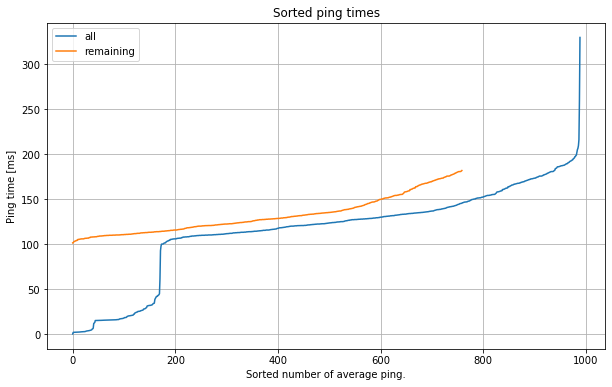

```python
# Plot the sorted ping times
figsize(10,6)
plot(list(sorted(df.avg_time)), label = 'all')
plot(list(sorted(df_fewer.avg_time)), label = 'remaining')
xlabel("Sorted number of average ping.")
ylabel("Ping time [ms]")
legend(loc="best")
title("Sorted ping times")
grid()
```

One can see from the figure above that real ping time starts from 100 ms, since there are many closer servers for American universites.

Below one can see the results on a folium map.

```python
plotmap(df_fewer)
```

[interactive chart not shown]

What is interesting to see here is how the average times scale as the distance increases i.e. going from East to West. The labels on the circlemarkers show the name of the institution and the average ping time. Furthermore, even after dropping out some outliers, there is still one relatively close to us, in Istanbul.

## Night Round

In this section I ran all the pingings between 6 PM and 10 PM (local time) and after a few days. This might result in some changes not only in the ping time, but as one will see, the urls and therefore the locations have also changed. The results for this can be seen in $\texttt{results_night}$ folder.

```python
df2 = read_in_ping_results(folder = 'results_night/')
get_locays(df2)
df2_fewer = dropsome(df2, 180, 50)
```

```
There were 1 error(s) for ['Marietta College'].
Those were placed at [0, 0]
```

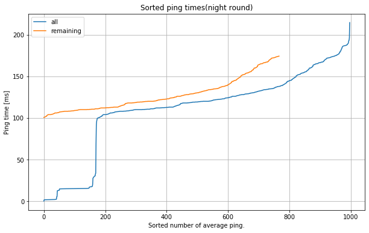

```python
# Plot the sorted ping times
figsize(10,6)
plot(list(sorted(df2.avg_time)), label = 'all')
plot(list(sorted(df2_fewer.avg_time)), label = 'remaining')
xlabel("Sorted number of average ping.")
ylabel("Ping time [ms]")
legend(loc="best")
title("Sorted ping times(night round)")
grid()
```

```python
plotmap(df2_fewer)
```

[interactive chart not shown]

The same shading can be seen here, too, with some outliers.

## Comparing

There are some problems with comparing the two. As I have mentioned, not only the ping times but the universites availability and the urls and locations also have changed.

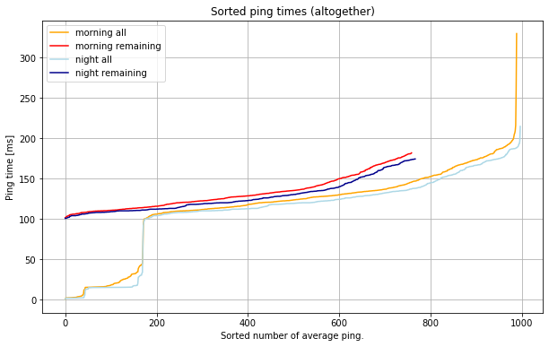

```python
# Combined plot
figsize(10,6)
plot(list(sorted(df.avg_time)),"orange" ,label = 'morning all')
plot(list(sorted(df_fewer.avg_time)), "red", label = 'morning remaining')
plot(list(sorted(df2.avg_time)), 'lightblue',label = 'night all')
plot(list(sorted(df2_fewer.avg_time)), 'darkblue',label = 'night remaining')
xlabel("Sorted number of average ping.")
ylabel("Ping time [ms]")
legend(loc="best")
title("Sorted ping times (altogether)")
grid()
```

From the picture above, one can see that the average ping time did decrease at night. The reason behind this might be that the overall network traffic decreased also.

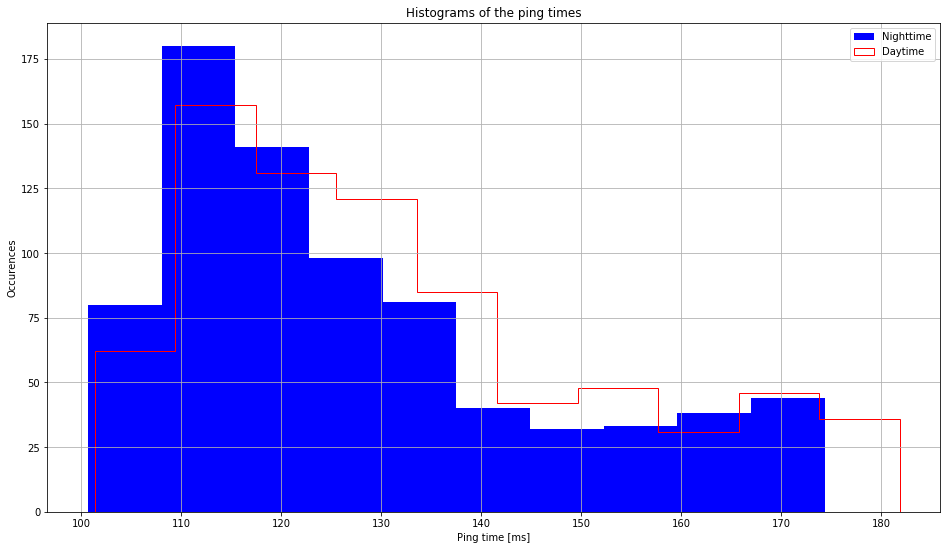

```python
# plotting histograms
figsize(16,9)
plt.grid()

plt.hist(df2_fewer.avg_time, label = 'Nighttime', color = 'blue');
plt.hist(df_fewer.avg_time, histtype="step", label = 'Daytime', color = 'red');
plt.xlabel("Ping time [ms]")
plt.ylabel("Occurences")
plt.title("Histograms of the ping times")
plt.legend(loc = "best");
```

The histograms indicate our suspicion, that there is a decrease in ping time at night. The shapes are similar but the nights' distribution is shifted to the left.

```python
print(f"# universities responded in the morning: {len(df)}, and in the night: {len(df2)}.")
```

```
# universities responded in the morning: 989, and in the night: 997.
```

```python
# Printing out differencies
print("Unis present in the morning\'s dataset, but not in the night\'s:")
for n in df.name:
    if n not in list(df2.name):
        print(f"\t{n}")

print("\nUnis present in the nights\'s dataset, but not in the mornings\'s:")

for n in df2.name:
    if n not in list(df.name):
        print(f"\t{n}")
```

```
Unis present in the morning's dataset, but not in the night's:
	University of Arkansas - Fort Smith
	Napa Valley College
	Houston Baptist University

Unis present in the nights's dataset, but not in the mornings's:
	Antioch University Los Angeles
	Rio Hondo College
	Santa Rosa Junior College
	Space Coast Health Institute
	Child Care Education Institute
	Piedmont College
	McDaniel College
	Saint James School
	Carleton College
	Valley City State University
	Misericordia University
```

To compare the results, I created a dataset consisting of all the overlapping institutions.

```python
df_section = pd.merge(df, df2, on='name', suffixes=['_d', '_n'])
```

```python
print(f"Shape of the section: {df_section.shape}")
df_section.head()
```

```
Shape of the section: (1008, 13)
```

|  | name | times_d | true_ip_d | url_d | avg_time_d | fileindex_d | locs_d | times_n | true_ip_n | url_n | avg_time_n | fileindex_n | locs_n |
| --- | --- | --- | --- | --- | --- | --- | --- | --- | --- | --- | --- | --- | --- |
| 0 | Alaska Christian College | [120.0, 119.0, 120.0, 120.0, 119.0, 119.0] | 184.154.231.31 | alaskacc.edu | 119.500000 | 1 | [41.8500, -87.6500] | [119.0, 119.0, 119.0, 120.0, 119.0, 120.0] | 184.154.231.31 | alaskacc.edu | 119.333333 | 1 | [41.8500, -87.6500] |
| 1 | Alabama A&M University | [138.0, 138.0, 139.0, 138.0, 138.0, 138.0] | 198.180.132.26 | aamu.edu | 138.166667 | 5 | [34.7890, -86.5719] | [137.0, 137.0, 136.0, 137.0, 136.0, 138.0] | 198.180.132.26 | aamu.edu | 136.833333 | 5 | [34.7890, -86.5719] |
| 2 | Athens State University | [190.0, 190.0, 190.0, 189.0, 189.0, 189.0] | 198.1.73.76 | athens.edu | 189.500000 | 6 | [40.2338, -111.6585] | [173.0, 173.0, 173.0, 175.0, 173.0, 173.0] | 198.1.73.76 | athens.edu | 173.333333 | 6 | [40.2338, -111.6585] |
| 3 | Birmingham-Southern College | [1.63, 2.01, 2.45, 1.82, 1.82, 2.3] | 104.26.1.60 | bsc.edu | 2.005000 | 9 | [40.7143, -74.0060] | [2.4, 1.73, 2.15, 1.45, 2.73, 2.14] | 104.26.0.60 | bsc.edu | 2.100000 | 9 | [40.7143, -74.0060] |
| 4 | Calhoun Community College | [130.0, 130.0, 130.0, 130.0, 130.0, 130.0] | 69.16.249.10 | calhoun.edu | 130.000000 | 10 | [42.7325, -84.5555] | [129.0, 130.0, 129.0, 130.0, 130.0, 129.0] | 69.16.249.10 | calhoun.edu | 129.500000 | 10 | [42.7325, -84.5555] |

```python
df_mismatch = df_section[df_section.locs_d != df_section.locs_n]
plot_diffmap(df_mismatch)
```

[interactive chart not shown]

On the map above, one can see the location changes. The morning places are marked with orange circle markers and the night locations are the blue normal ("popup") markers. The green lines are connecting the different places for a given university. There are also blue arrows on the lines, which are showing the "move" of a uni. Since there is no real moving (or at least I hope so, see [here](https://www.theguardian.com/world/2019/nov/16/ceu-classes-move-to-vienna-orban-hungary-ousts-university)) of the institutions, only the IP's are the ones that change. And apart from three unidirectional changes (Chicago, LA and Europe), most connections are bidirectional. This means that those are somewhat connected to each other, for example, in the case of the Southwestern College (see df below), this college has two entries in the provided excel sheet also. One in Miami and one in California. All the bidirectional connections are like this (or even more complicated, see the San Antonio, Virginia Beach and NY triangle).

Since this is only a small portion of all the overlay (14 rows only), the others can be compared.

```python
df_mismatch[df_mismatch.name=="Southwestern College"]
```

|  | name | times_d | true_ip_d | url_d | avg_time_d | fileindex_d | locs_d | times_n | true_ip_n | url_n | avg_time_n | fileindex_n | locs_n |
| --- | --- | --- | --- | --- | --- | --- | --- | --- | --- | --- | --- | --- | --- |
| 169 | Southwestern College | [173.0, 159.0, 174.0, 283.0, 169.0, 176.0] | 12.116.132.138 | swcc.edu | 189.000000 | 303 | [26.2379, -80.1248] | [153.0, 152.0, 152.0, 152.0, 153.0, 153.0] | 66.33.205.38 | swc.edu | 152.5 | 1176 | [33.9167, -117.9001] |
| 170 | Southwestern College | [155.0, 154.0, 153.0, 153.0, 153.0, 152.0] | 66.33.205.38 | swc.edu | 153.333333 | 1176 | [33.9167, -117.9001] | [178.0, 145.0, 145.0, 175.0, 145.0, 205.0] | 12.116.132.138 | swcc.edu | 165.5 | 303 | [26.2379, -80.1248] |

```python
for l in df_mismatch.index:
    try:
        df_section.drop(l, inplace=True)
    except KeyError:
        continue
print(f"Shape of the remaining section: {df_section.shape}")
```

```
Shape of the remaining section: (994, 13)
```

```python
df_section['avg_time'] = df_section.avg_time_n - df_section.avg_time_d
df_section['locs'] = df_section.locs_d
df_section_fewer = dropsome(df_section, 20, 10)
```

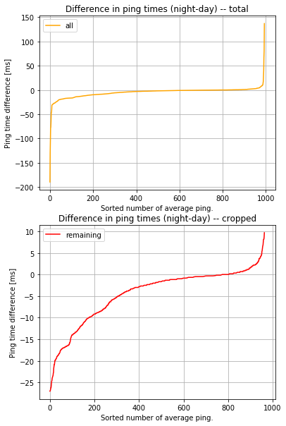

```python
# Plot of the differences
figsize(6, 10)
plt.subplot(2,1,1)
plot(list(sorted(df_section.avg_time)),"orange" ,label = 'all')
xlabel("Sorted number of average ping.")
ylabel("Ping time difference [ms]")
legend(loc="best")
title("Difference in ping times (night-day) -- total")
grid()
plt.subplot(2,1,2)
plot(list(sorted(df_section_fewer.avg_time)), "red", label = 'remaining')
xlabel("Sorted number of average ping.")
ylabel("Ping time difference [ms]")
legend(loc="best")
title("Difference in ping times (night-day) -- cropped")
grid()
```

The two figures show the difference between the average ping time at night and at daytime. As it is clear on the second figure, the average is below 0, indicating an increase in speed (decrease in ping time). Please note that here I only dropped 20 points from the faster ones and 10 from the slowest ones.

```python
print(f"The mean of the differences: {df_section_fewer.avg_time.mean()}.")
print(f"The standard deviation of the differences: {df_section_fewer.avg_time.std()}.")
```

```
The mean of the differences: -4.436469052558784.
The standard deviation of the differences: 6.397550850459039.
```

```python
plotmap(df_section_fewer)
```

[interactive chart not shown]

On the map above one can see the differences between the night time and daytime. If the difference is negative the marker is greener, meaning that there was a decrease from day to night i.e. it is faster to access these points. If the marker is more blue, that indicates an icrease in ping time.

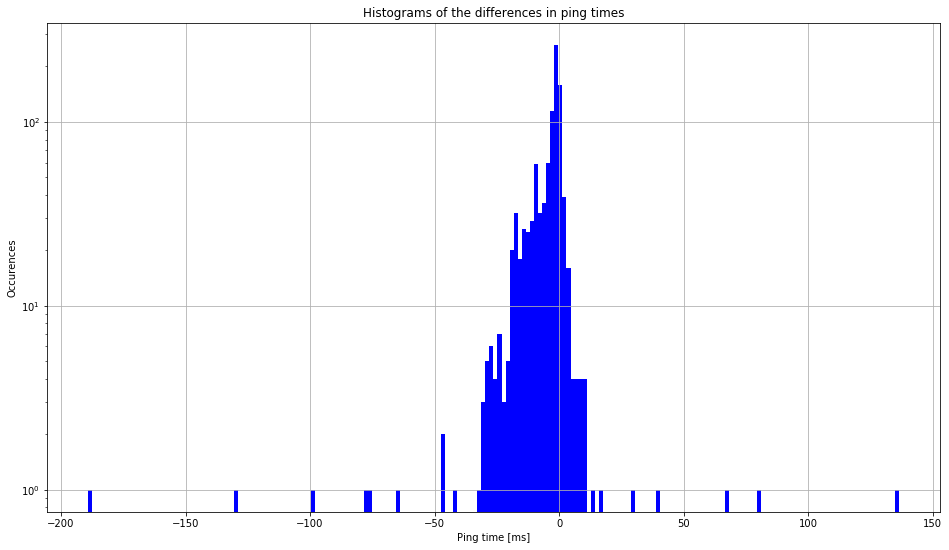

```python
# plotting histogram
figsize(16,9)
plt.grid()

plt.hist(df_section.avg_time,bins = 200, color = 'blue');
plt.xlabel("Ping time [ms]")
plt.ylabel("Occurences")
plt.yscale("log")
plt.title("Histograms of the differences in ping times");
```

This histogram shows also that most of the ping times decreased. Please note that the y scale is logarithmic.